# Exercise_3_MS

April 15, 2021

## Exercise 1

## *Outlander* (TV Series)<sup>1</sup>

**Outlander** is an historical drama television series based on the ongoing novel series of the same name by *Diana Gabaldon*. Developed by *Ronald D. Moore*, the show premiered on August 9, 2014, on Starz. It stars *Caitriona Balfe* as Claire Randall, a married former World War II military nurse in Scotland who, in 1945, finds herself transported back to 1743. There she encounters the dashing Highland warrior Jamie Fraser (*Sam Heughan*), a member of Gabaldon’s fictionalized version of Clan Fraser of Lovat, and becomes embroiled in the Jacobite rising.

The 16-episode first season of the television series (released as two half-seasons) is based on the first novel in the series, Outlander (known as *Cross Stitch* in the U.K.). The second season of 13 episodes, based on Dragonfly in Amber, aired from April to July 2016. The 13-episode third season, based on Voyager, aired from September to December 2017. The 13-episode fourth season, based on Drums of Autumn, aired from November 2018 to January 2019. The fifth season of 12 episodes, based on The Fiery Cross, aired from February to May 2020.

The series has been renewed for 12-episode sixth and seventh seasons to be based on A Breath of Snow and Ashes and An Echo in the Bone.

[figure not shown]

## Viewership and ratings

| Season | Timeslot (ET) | Episodes | First aired date | First aired avg. viewers (millions) | Last aired date | Last aired avg. viewers (millions) | Avg. viewers (millions) | Avg. 18–49 rating |
| --- | --- | --- | --- | --- | --- | --- | --- | --- |
| 1 | Saturday 9:00 pm | 16 | August 9, 2014 | 0.72 | May 30, 2015 | 0.98 | 1.04 | 0.26 |
| 2 | Saturday 9:00 pm | 13 | April 9, 2016 | 1.46 | July 9, 2016 | 1.15 | 1.09 | 0.22 |
| 3 | Sunday 8:00 pm | 13 | September 10, 2017 | 1.49 | December 10, 2017 | 1.43 | 1.51 | 0.32 |
| 4 | Sunday 8:00 pm | 13 | November 4, 2018 | 1.08 | January 27, 2019 | 1.45 | 1.04 | 0.17 |
| 5 | Sunday 8:00 pm | 12 | February 16, 2020 | 0.82 | May 10, 2020 | 0.86 | 0.81 | 0.12 |

## Graph 1

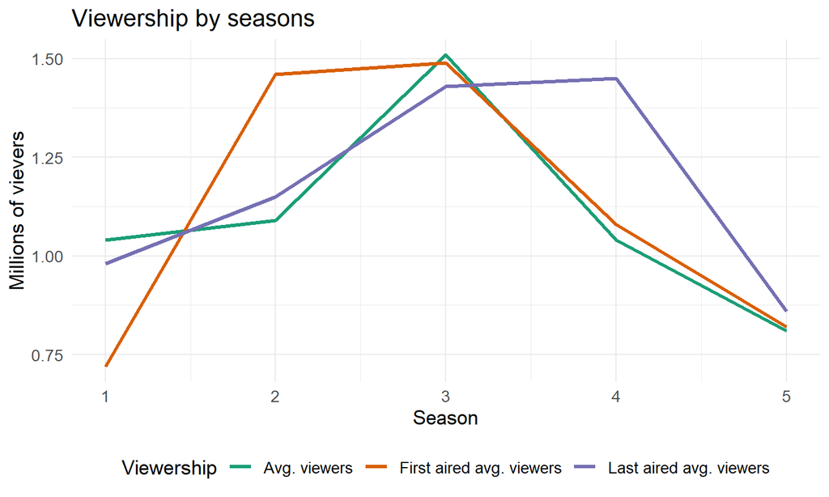

## Graph 2

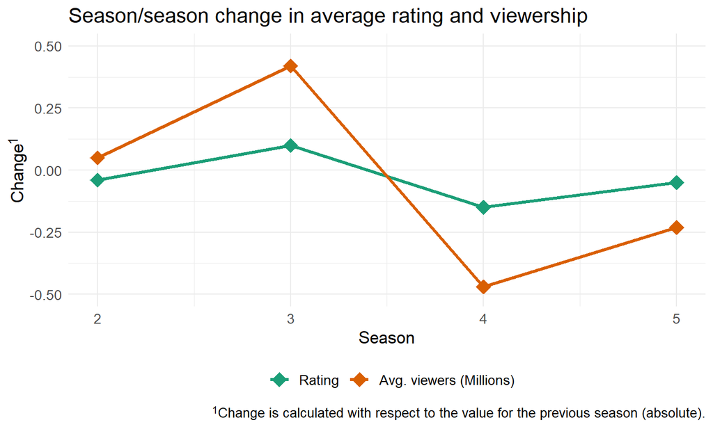

## Summary

Season 3, which was the most popular one, was also best rated by the audience. It was viewed by 1.51 million viewers on average and was rated 0.32. The series’ popularity measured by the number of viewers and the ratings were tangibly correlated. After season 3, season 4 brought the most significant decline in absolute terms both in the rating and in the audience, which shrinked by 0.47 millions, reaching 1.04 M. The 5<sup>th</sup> and last season to date, with the last episode aired on May 10, 2020, continued the negative trend: the series lost another 0.23 million viewers, reaching 0.81 M, and the average score was only 0.12.

## Exercise 2

## Game of Thrones - Season 1 summary in numbers

### **(*Warning:* spoilers ahead)**

## Overview

(From the [Wikipedia](https://en.wikipedia.org/wiki/Game_of_Thrones#Premise)) Game of Thrones is an American fantasy drama television series created by David Benioff and D. B. Weiss for HBO. It is an adaptation of A Song of Ice and Fire, a series of fantasy novels by George R. R. Martin, the first of which is A Game of Thrones’ Set on the fictional continents of Westeros and Essos, Game of Thrones has a large ensemble cast and follows several story arcs throughout the course of the show. A major arc concerns the Iron Throne of the Seven Kingdoms of Westeros through a web of political conflicts among the noble families either vying to claim the throne or fighting for independence from it. Another focuses on the last descendant of the realm’s deposed ruling dynasty, who has been exiled to Essos and is plotting a return to the throne. A third story arc follows the Night’s Watch, a military order defending the realm against threats from the North.

## Season 1 summary

Season 1 of Game of Thrones consisted of 10 episodes that aired between April 17, 2011 and June 19, 2011, on HBO. The show gathered an average of 2.52 million first-day viewers in the US, with the smallest number of 2.2 M viewers for *The Kingsroad* and the largest ber of 3.04 M viewers for *Fire and Blood*. The first episode in the season, *Winter Is Coming*, gathered 2.22 M audience, and the last one, *Fire and Blood* - 3.04 M.

The most popular episode of the season was *Fire and Blood*, in which:

The North secedes from the Seven Kingdoms and proclaims Robb as king. With Jaime as the Starks’ prisoner and Robert’s two brothers, Stannis and Renly, each challenging Joffrey’s claim to the throne, Tywin appoints Tyrion as acting King’s Hand, while Tywin fights to defend Joffrey’s reign. Jon attempts to desert the Night’s Watch to avenge Ned and join Robb, but his Night’s Watch brothers convince him to honor his oath. Jon joins an expedition to search for Benjen Stark beyond the Wall. Yoren, a Night’s Watch recruiter, smuggles Arya out of King’s Landing disguised as a boy, while Joffrey intends to crown Sansa his queen, despite executing her father. Daenerys’s baby is born deformed and dead, and Drogo is left in a vegetative state by the witch’s treacherous magic. Daenerys compassionately ends Drogo’s life. She places the three dragon eggs on Drogo’s funeral pyre and sets it afire, also burning the witch alive. Ignoring Jorah’s pleas, she walks into the flames. When the embers die the following morning, Daenerys is found in the ashes, unharmed, flanked by three newly-hatched baby dragons. Jorah and other witnesses kneel before her.

## Here is how the viewership of the episodes changed:

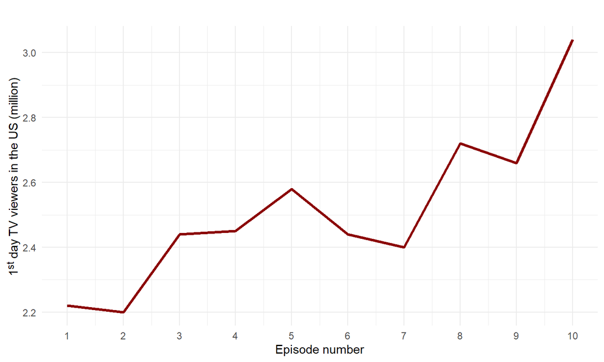

## Finally, the episodes with the above-average viewership were:

| No. in season | Title | Directed by | No. of viewers (M) |
| --- | --- | --- | --- |
| 5 | The Wolf and the Lion | Brian Kirk | 2.58 |
| 8 | The Pointy End | Daniel Minahan | 2.72 |
| 9 | Baelor | Alan Taylor | 2.66 |
| 10 | Fire and Blood | Alan Taylor | 3.04 |